# Profiling of single-clone organoids obtained from the AHM2392 HGD-derived organoid

2025-05-23

In this script, we will conduct complete profiling of single-clone organoids derived from an organoid obtained from the HGD patient AHM2392. This include:

- Profiling of mutation overlap and concordance with the matched bulk organoid and tissue, and demonstration of clonality within the organoids.
- Demonstration of shared mutations and OAC drivers (as defined by Frankell et al. 2019)
- Mutational signature analysis
- Phylogenetic analysis and branch-signature assignment
- Concordance with RNA-seq data, and alignment on a gastric-intestinal axis

```r
library(readxl) # to read excel files
library(tidyverse) # data table manipulation
library(vcfR) # to read VCF files
```

```r
library(biomaRt) # for Ensembl access
library(ComplexHeatmap) # for oncoplot generation
library(circlize)
library(deconstructSigs) # signature fitting
library(BSgenome.Hsapiens.UCSC.hg19) # hg19 reference for context determination
library(ggplot2) # plotting
library(ggpubr) # statistics in plotting
library(phangorn) # phylogenetic analysis
library(ggtree) # for tree plotting
library(reshape2)
library(EnsDb.Hsapiens.v79) # Ensembl gene ID access
library(SummarizedExperiment) # RNA-seq data processing
library(DESeq2) # Further RNA-seq processing
library(vsn) # variance stabilizing transformation
library(pheatmap) # heatmap plotting for RNA-seq
library(RColorBrewer) # colour gradients
```

# 1 Concordance and Clonality

To begin, we can load in the full set of SNV and indel data in order to demonstrate:

- Clonality: by virtue of how these organoids are derived, they should represent an individual clone. Consequently, the mutations should show a Normal distribution of VAFs with a mean of 50%.
- Concordance: these organoids should display significant overlap with their matched tissue, bulk organoid, and also their neighbouring clonal organoids.

## 1.1 VCF processing and data collection

We can start by collecting the relevant metadata for our WGS analysis

```r
meta <- read_excel('Data/WGS for organoid paper_to Daniel and Ginny.xlsx', skip=3)

meta.ahm <- meta %>%
  dplyr::filter(`Patient ID` == 'AHM2392' & `Type/site` == 'Esophagus') %>%
  mutate(`Sample ID` = sapply(`Sample ID`, function(x) str_replace(x, pattern = 'BE', replacement = 'BO')))
```

Next, we can establish the set of files to load in, from which we can derive our matched indices for our metadata.

Once these are defined, for each file:

- read in information
- if SNVs (as opposed to indels), the obtain the VAFs
- write into shared file

```r
# Establish files
sample.files <- list.files(pattern = '.vcf$', recursive = TRUE)

sample.files_index <- sapply(sample.files, function(x) strsplit(strsplit(x,split='_vs_')[[1]][1],split='[.]')[[1]][2])
sample.files_index <- sapply(sample.files_index, function(x) paste(strsplit(x,split='_')[[1]],collapse='-'))

# Read in data and initialise data frame for tracking TMB
muts.full <- data.frame()
df.tmb <- data.frame()

for (file in sample.files) {

  # Read in file
  seqID.i <- sapply(file, function(x) strsplit(strsplit(x,split='/')[[1]][4], split='_vs_')[[1]][1])
  vcf.i <- read.vcfR(file, verbose = FALSE)@fix %>% as.data.frame

  # Track number of mutations in df.tmb (this will include SNVs and indels)
  df.tmb <- rbind(df.tmb,
                  data.frame(sequence_id = seqID.i,
                             num_mutations = nrow(vcf.i)))

  # Add specimen info
  index <- strsplit(strsplit(file, split='_vs_')[[1]][1], split='[.]')[[1]][2]
  index <- gsub('_','-',paste0('SLX-21323.',index))

  if (index %in% meta.ahm$Index) {

    specimenID <- meta.ahm$`Sample ID`[meta.ahm$Index == index]

    vcf.i$SPECIMEN_ID <- specimenID

    # Add depth and VAF info
    if (grepl(pattern = '.snp.pass.vcf', file)) {
      vcf.i$DEPTH <- sapply(vcf.i$INFO, function(x) as.numeric(strsplit(strsplit(x,split=';')[[1]][1],split='=')[[1]][2]))
      vcf.i$VAF <- sapply(vcf.i$INFO, function(x) as.numeric(strsplit(strsplit(x,split=';')[[1]][28],split='=')[[1]][2]))
    } else {
      vcf.i$DEPTH <- NA
      vcf.i$VAF <- NA
    }

    # Save output (remove full INFO column)
    muts.full <- rbind(muts.full, vcf.i[,-8])

  }

}

# Summarise mutation counts
df.tmb <- df.tmb %>% group_by(sequence_id) %>% summarise(n_mutation = sum(num_mutations)) %>%
  mutate(TMB = n_mutation/3100)

# # Save output
# write.table(muts.full, file = 'Data/WGS/strelka/AHM2392_allVCFs.txt',
#             sep ='\t', quote = FALSE, row.names = FALSE, col.names = TRUE)
```

## 1.2 Check VAF distributions across samples

Here, we want to check that the VAFs of the single-clonal organoid are Normally distributed. We can remove the matched OAC organoid/tissue from the final plot

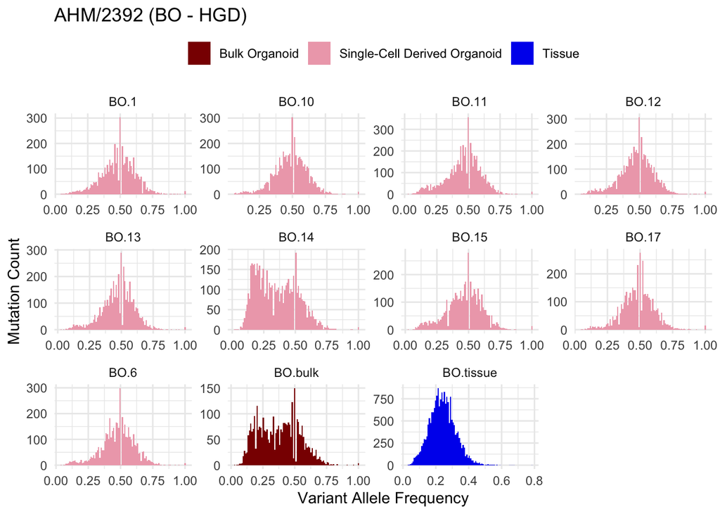

```r
# Create snappier titles for each organoid (remove 'OGD_AHM2392' and matrigel information)
muts.full$SPECIMEN_ID_short <- sapply(muts.full$SPECIMEN_ID, function(x) strsplit(x,split='_')[[1]][2])
muts.full$SPECIMEN_ID_short <- sapply(muts.full$SPECIMEN_ID_short, function(x) substr(x,9,nchar(x)))
muts.full$SPECIMEN_ID_short[muts.full$SPECIMEN_ID_short == 'BO'] <- 'BO.bulk'

# Add tissue ID
muts.full$SPECIMEN_ID_short[muts.full$SPECIMEN_ID == 'AHM2392.BO-tissue'] <- 'BO.tissue'

# Add organoid type
muts.full$OrganoidType <- sapply(muts.full$SPECIMEN_ID, function(x)
  ifelse(x == 'OGD_AHM2392.BO_OWR_P1', 'Bulk Organoid',
         ifelse(x == 'AHM2392.BO-tissue', 'Tissue', 'Single-Cell Derived Organoid')))

ggplot(muts.full[!(muts.full$SPECIMEN_ID %in% c('AHM2392.T-tissue','OGD_AHM2392.T (OD)_INC_P5')), ],
       aes(x = VAF, fill = OrganoidType)) +
  geom_histogram(bins = 100) + theme_minimal() +
  scale_fill_manual(values = c('darkred','pink2', 'blue2')) +
  facet_wrap(~SPECIMEN_ID_short, scales = 'free') +
  theme(legend.position = 'top', legend.title = element_blank()) +
  labs(x = 'Variant Allele Frequency', y = 'Mutation Count') +
  ggtitle('AHM/2392 (BO - HGD)')
```

```r
ggsave(filename = 'Results/AHM2392_VAFdistributions.pdf',
       width = 8, height = 8)
```

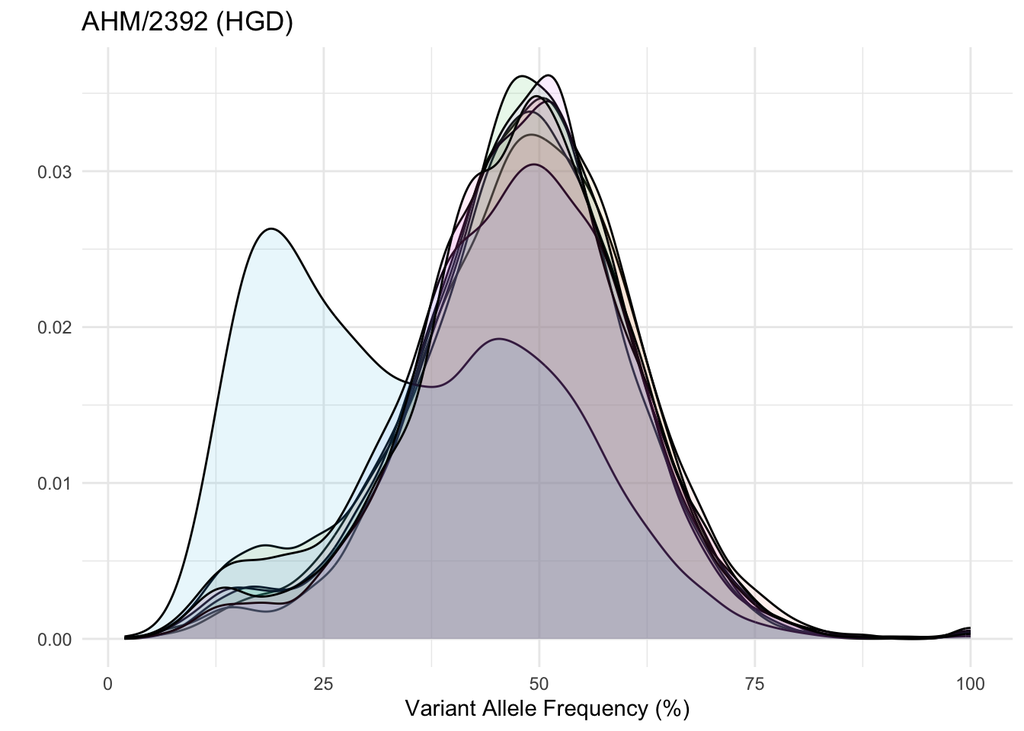

```r
ggplot(muts.full[!(muts.full$SPECIMEN_ID %in% c('AHM2392.T-tissue','OGD_AHM2392.T (OD)_INC_P5',
                                                'AHM2392.BO-tissue','OGD_AHM2392.BO_OWR_P1')),],
       aes(x = 100*VAF, fill = SPECIMEN_ID_short)) +
  geom_density(alpha = .1) + theme_minimal() +
  theme(legend.position = 'none') +
  labs(x = 'Variant Allele Frequency (%)', y = '') +
  ggtitle('AHM/2392 (HGD)')
```

```r
ggsave(filename = 'Results/AHM2392_VAFdistributions_noFacet.pdf',
       width = 5, height = 5)
```

As we can see, whilst the bulk samples (organoid and tissue) display patterns of subclonality, the single-clonal organoids only describe individual clones. The one exception is BO.14, which appears to have manifested a subclonal expansion. This could be a consequence of an acquired mutation during organoid development, or simply a lack of subclonality during initial seeding.

## 1.3 Check mutational concordance across organoids

Now we can determine the extent of overlap across the organoids. The concordance across the AHM2392 bulk tissue and organoid is determined previously, so here we shall focus on concordance between the bulk and single-clonal organoids.

```r
# Generate mutation IDs and separate into bulk and sc-derived mutations, noting the removal of the tissue sample
muts.full$MUTATION_ID <- apply(muts.full, 1, function(x)
  paste(x['CHROM'],x['POS'],x['REF'],x['ALT'], sep = '_'))

muts.bulk <- muts.full %>% dplyr::filter(SPECIMEN_ID == 'OGD_AHM2392.BO_OWR_P1')
muts.sc <- muts.full %>% dplyr::filter(!(SPECIMEN_ID %in% c('OGD_AHM2392.BO_OWR_P1','AHM2392.BO-tissue',
                                                            'OGD_AHM2392.T (OD)_INC_P5','AHM2392.T-tissue')))

# Pivot out muts.sc to see shared mutations across sc-derived organoids
muts.sc <- muts.sc %>%
  dplyr::select(MUTATION_ID, SPECIMEN_ID_short, VAF) %>%
  pivot_wider(names_from = SPECIMEN_ID_short, values_from = VAF) %>%
  column_to_rownames(var = 'MUTATION_ID')

# Label mutations as 'Private' or 'Shared with SC-Organoids'
#   and label those found in muts.bulk as 'Shared with Bulk'

muts.sc$Label <- apply(muts.sc, 1, function(x) ifelse(sum(!is.na(x)) == 1,
                                                      'Private', 'Shared with an sc-organoid'))
muts.sc$Label[rownames(muts.sc) %in% muts.bulk$MUTATION_ID] <- 'Shared with Bulk Organoid'

# Pivot back and summarise muts.sc table for plotting
muts.sc_summary <- muts.sc %>%
  mutate(MUTATION_ID = rownames(muts.sc)) %>%
  pivot_longer(cols = -c(MUTATION_ID, Label), names_to = 'SPECIMEN_ID', values_to = 'VAF') %>%
  dplyr::filter(!is.na(VAF)) %>%
  group_by(SPECIMEN_ID, Label) %>%
  summarise(num_mutations = n()) %>%
  mutate(Label = factor(Label, levels = c('Private', 'Shared with an sc-organoid', 'Shared with Bulk Organoid')))
```

```
## `summarise()` has regrouped the output.
## ℹ Summaries were computed grouped by SPECIMEN_ID and Label.
## ℹ Output is grouped by SPECIMEN_ID.
## ℹ Use `summarise(.groups = "drop_last")` to silence this message.
## ℹ Use `summarise(.by = c(SPECIMEN_ID, Label))` for per-operation grouping
##   (`?dplyr::dplyr_by`) instead.
```

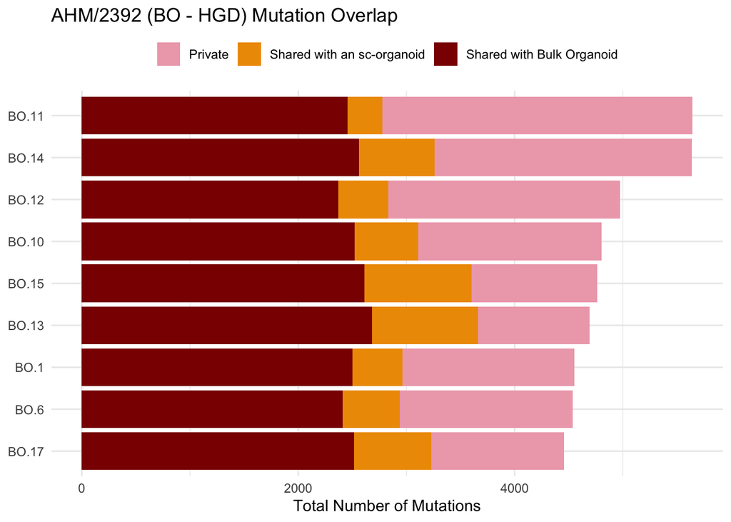

```r
# Rank organoids by total mutations shared with bulk organoid
muts.total <- muts.sc_summary %>%
  group_by(SPECIMEN_ID) %>%
  summarise(num_total = sum(num_mutations)) %>%
  arrange(num_total)
muts.sc_summary$SPECIMEN_ID <- factor(muts.sc_summary$SPECIMEN_ID,
                                      levels = muts.total$SPECIMEN_ID)

# Plot the overall concordances
ggplot(muts.sc_summary, aes(x = num_mutations, y = SPECIMEN_ID, fill = Label)) +
  geom_bar(stat = 'identity') + theme_minimal() +
  xlab('Total Number of Mutations') +
  theme(legend.position = 'top', legend.title = element_blank(),
        axis.title.y = element_blank()) +
  scale_fill_manual(values = c('pink2','orange2','darkred')) +
  ggtitle('AHM/2392 (BO - HGD) Mutation Overlap')
```

```r
ggsave(filename = 'Results/AHM2392_SharedMutations.pdf')
```

## 1.4 Generate oncoplot

We can provide a visual representation of the OAC-linked driver events which are shared, and deviate, across the single-clonal organoids, bulk organoids, and tissue.

We can begin by loading in coding events (subsetting for OAC drivers), and identifying CNAs in these respective genes

```r
# Since we will only analyse OAC driver genes, load this gene list
gene_drivers.file <- read_excel('Data/41588_2018_331_MOESM3_ESM.xlsx',
                                sheet = 'ST9 All Drivers dnds ratios',
                                skip = 2)
gene_drivers <- gene_drivers.file$gene_name

# Load SNV/indel data
vep.files <- list.files(path = 'Data/WGS/strelka', pattern = '.pass.coding.supplemented.vep$',
                        recursive = TRUE, full.names = TRUE)
vep.full <- data.frame()

for (file in vep.files) {

  if (readLines(file) %>% length > 1) {

    vep.i <- read.delim(file, skip=1, header = FALSE)

    if (ncol(vep.i) == 18) {

      vep.i <- vep.i[,c(2,3,11,18)]
      names(vep.i) <- c('sequence_id','mutationID','mutationType','Extra')
      vep.i <- vep.i %>% dplyr::filter(!duplicated(mutationID))
      vep.i$Gene <- sapply(vep.i$Extra, function(x)
        strsplit(strsplit(x,split=';')[[1]][2],split='=')[[1]][2])

      vep.full <- rbind(vep.full, vep.i[,-4])

    } else if (ncol(vep.i) == 16) {

      vep.i <- vep.i[,c(2,3,9,16)]
      names(vep.i) <- c('sequence_id','mutationID','mutationType','Extra')
      vep.i <- vep.i %>% dplyr::filter(!duplicated(mutationID))
      vep.i$Gene <- sapply(vep.i$Extra, function(x)
        strsplit(strsplit(x,split=';')[[1]][2],split='=')[[1]][2])

      vep.full <- rbind(vep.full, vep.i[,-4])

    } else {
      print(paste0('Check column numbers in file: ',file))
    }

  }

}

# Subset on OAC driver genes
vep.oac <- vep.full %>% dplyr::filter(Gene %in% gene_drivers)
vep.oac$sequence_id <- sapply(vep.oac$sequence_id, function(x) strsplit(x,split='_vs_')[[1]][1])

vep.oac <- vep.oac %>%
  group_by(sequence_id, mutationID, Gene, mutationType) %>%
  summarise(Present = 1)
```

```
## `summarise()` has regrouped the output.
## ℹ Summaries were computed grouped by sequence_id, mutationID, Gene, and
##   mutationType.
## ℹ Output is grouped by sequence_id, mutationID, and Gene.
## ℹ Use `summarise(.groups = "drop_last")` to silence this message.
## ℹ Use `summarise(.by = c(sequence_id, mutationID, Gene, mutationType))` for
##   per-operation grouping (`?dplyr::dplyr_by`) instead.
```

```r
write.csv(vep.oac, file = 'Results/ClonalOrganoids_AHM2392_summaryVEP.csv')
```

We can repeat data colleciton for CNAs. Here, we use Ensembl to match OAC-linked driver genes with their positions, which are then matched to the respective ASCAT output. Alterations are then highlighted and extracted.

```r
# Define copy number files
files.caveman <- list.files(path = 'Data/WGS/ascat', pattern = '.copynumber.caveman.csv',
                            recursive = TRUE, full.names = TRUE)
files.ploidy <- list.files(path = 'Data/WGS/ascat', pattern = 'samplestatistics.csv',
                           recursive = TRUE, full.names = TRUE)

# Define data frame to track ploidy
df.ploidy <- data.frame()

# In this case, we will start with the gene list and match the copy number profiles


load('~/Documents/Data/mart.homosapiens.hg19.Rdata')
gene_positions <- getBM(
  attributes = c('hgnc_symbol','chromosome_name','start_position','end_position'),
  filters = c('hgnc_symbol'),
  values = list(gene_drivers),
  mart=mart
)
gene_positions <- gene_positions %>% dplyr::filter(chromosome_name %in% c(1:22,'X','Y'))


# Define 'by' statement for joining with caveman output
by = join_by(
  chromosome_name == Chromosome,
  start_position >= Start,
  end_position <= End
)

# Now we ascribe the CNVs
cnv.full <- data.frame()

for (i in 1:length(files.caveman)) {

  seqID.i <- strsplit(strsplit(files.ploidy[i], split='/')[[1]][4], split='_vs_')[[1]][1]
  ploidy.i <- read.delim(files.ploidy[i],h=F,sep=' ')[2,2]
  df.ploidy <- rbind(df.ploidy, data.frame(sequence_id = seqID.i,
                                           ploidy = ploidy.i))

  ploidy.i <- read.delim(files.ploidy[i],h=F,sep=' ')[2,2]

  caveman.i <- read.csv(files.caveman[i])
  caveman.i$Chromosome <- as.character(caveman.i$Chromosome)
  genes.i <- left_join(gene_positions, caveman.i, by)

  # Label CNVs based on Li, Francies et al. 2018
  genes.i$CNV <- NA
  # genes.i$CNV[genes.i$Total_CN >= 1.25*ploidy.i] <- 'Gain'
  genes.i$CNV[genes.i$Total_CN >= 2*ploidy.i] <- 'Amplification'
  # genes.i$CNV[genes.i$Total_CN >= 3 & genes.i$hgnc_symbol %in% c('NOTCH1','KCNQ3')] <- 'Amplification'
  # genes.i$CNV[genes.i$Total_CN <= 0.75*ploidy.i] <- 'Loss'
  genes.i$CNV[genes.i$Minor_CN == 0] <- 'Loss'
  genes.i$CNV[genes.i$Total_CN == 0 & genes.i$Minor_CN == 0] <- 'Deletion'

  genes.i <- genes.i %>% dplyr::filter(!is.na(CNV))

  if (nrow(genes.i) > 0) {

    # Extract sequencingID for matching
    genes.i$sequence_id <- strsplit(strsplit(files.caveman[i], split='/')[[1]][4],split='_vs_')[[1]][1]

    cnv.full <- rbind(cnv.full, genes.i)

  }

}

# Align with vep.oac
cnv.oac <- cnv.full[,c('sequence_id', 'hgnc_symbol','CNV')]
names(cnv.oac) <- c('sequence_id','Gene','mutationType')

muts.oac <- rbind(vep.oac[,c('sequence_id','Gene','mutationType')], cnv.oac)
```

Now we need to start preparing our data for oncoplotting via ComplexHeatmaps. This involves fixing our mutation-type labels (often these SNVs are assigned multiple definitions), and then preparing our plotting matrix and annotation data frame.

```r
# Fix mutation type
muts.oac <- muts.oac %>% dplyr::filter(grepl(pattern = 'missense_variant', mutationType) |
                                  grepl(pattern = 'frameshift_variant', mutationType) |
                                  grepl(pattern = 'stop_gained', mutationType) |
                                  grepl(pattern = 'inframe_', mutationType) |
                                  grepl(pattern = 'NMD_transcript_variant', mutationType) |
                                  mutationType %in% c('Deletion','Loss','Amplification'))
muts.oac$mutationType[grepl(pattern = 'NMD_transcript_variant', muts.oac$mutationType)] <- 'NMD_transcript_variant'
muts.oac$mutationType[muts.oac$mutationType == 'frameshift_variant,splice_region_variant'] <- 'frameshift_variant'
muts.oac$mutationType[muts.oac$mutationType == 'missense_variant,splice_region_variant'] <- 'missense_variant'

# Organise data for oncoplot
#   Group by sequence_id+Gene to generate a single mutationLabel

muts.oac$specimen_source <- 'Single-Cell Derived Organoid'
muts.oac$specimen_source[muts.oac$sequence_id == 'SLX-21323.i701_i505'] <- 'Tissue (HGD)'
muts.oac$specimen_source[muts.oac$sequence_id == 'SLX-21323.i703_i517'] <- 'Bulk Organoid (HGD)'
muts.oac$specimen_source[muts.oac$sequence_id == 'SLX-21323.i701_i506'] <- 'Bulk Organoid (OAC)'
muts.oac$specimen_source[muts.oac$sequence_id == 'SLX-21323.i703_i506'] <- 'Tissue (OAC)'

muts.oac_plot <- muts.oac %>%
  group_by(sequence_id, specimen_source, Gene, mutationType) %>%
  summarise(Present = n()) %>%
  group_by(sequence_id, specimen_source, Gene) %>%
  summarise(mutationLabel = paste(mutationType, collapse=';')) %>%
  mutate(mutationLabel = paste0(mutationLabel,';'))
```

```
## `summarise()` has regrouped the output.
## `summarise()` has regrouped the output.
## ℹ Summaries were computed grouped by sequence_id, specimen_source, Gene, and
##   mutationType.
## ℹ Output is grouped by sequence_id, specimen_source, and Gene.
## ℹ Use `summarise(.groups = "drop_last")` to silence this message.
## ℹ Use `summarise(.by = c(sequence_id, specimen_source, Gene, mutationType))`
##   for per-operation grouping (`?dplyr::dplyr_by`) instead.
```

```r
# Pivot out to generate a matrix: row = sequence_id, col = Gene
muts.oac_plot <- muts.oac_plot[,c('sequence_id','Gene','mutationLabel')] %>%
  pivot_wider(names_from = sequence_id, values_from = mutationLabel) %>%
  column_to_rownames(var = 'Gene') %>% as.matrix
muts.oac_plot[is.na(muts.oac_plot)] <- ''

# Prepare annotation file, and set the order of columns (inc.order occams.id by #samples)
muts.oac_ann <- muts.oac %>%
  group_by(specimen_source, sequence_id) %>%
  summarise(driver_count = n())
```

```
## `summarise()` has regrouped the output.
## ℹ Summaries were computed grouped by specimen_source and sequence_id.
## ℹ Output is grouped by specimen_source.
## ℹ Use `summarise(.groups = "drop_last")` to silence this message.
## ℹ Use `summarise(.by = c(specimen_source, sequence_id))` for per-operation
##   grouping (`?dplyr::dplyr_by`) instead.
```

```r
# Load clinical data and add relevant information
muts.oac_ann$specimen_source <- factor(muts.oac_ann$specimen_source,
                                       levels = c('Tissue (OAC)', 'Bulk Organoid (OAC)',
                                                  'Tissue (HGD)', 'Bulk Organoid (HGD)', 'Single-Cell Derived Organoid'))
muts.oac_ann <- muts.oac_ann %>% arrange(specimen_source, desc(driver_count))

muts.oac_plot <- muts.oac_plot[,muts.oac_ann$sequence_id]


# Prepare anno_barplot for right_annotation
annoMut <- muts.oac %>%
  group_by(Gene, mutationType) %>% summarise(n = n()) %>%
  pivot_wider(names_from = 'mutationType', values_from = n, values_fill = 0) %>%
  column_to_rownames(var = 'Gene') %>% as.matrix
```

```
## `summarise()` has regrouped the output.
## ℹ Summaries were computed grouped by Gene and mutationType.
## ℹ Output is grouped by Gene.
## ℹ Use `summarise(.groups = "drop_last")` to silence this message.
## ℹ Use `summarise(.by = c(Gene, mutationType))` for per-operation grouping
##   (`?dplyr::dplyr_by`) instead.
```

```r
# Informaiton for oncoplot input
col.bars = c("Amplification" = "darkred", "Deletion" = "turquoise3", "Loss" = "lightblue",
             'inframe_deletion' = 'orange3',
             'missense_variant' = 'red2', 'NMD_transcript_variant' = 'darkgreen', 'stop_gained' = 'purple3')
alter_fun = list(
  background = alter_graphic("rect", fill = "gray90"),
  Amplification = alter_graphic("rect", fill = col.bars["Amplification"]),
  Deletion = alter_graphic("rect", fill = col.bars["Deletion"]),
  Loss = alter_graphic("rect", fill = col.bars["Loss"]),
  inframe_deletion = alter_graphic("rect", height = 0.33, fill = col.bars["inframe_deletion"]),
  missense_variant = alter_graphic("rect", height = 0.33, fill = col.bars["missense_variant"]),
  NMD_transcript_variant = alter_graphic("rect", height = 0.33, fill = col.bars["NMD_transcript_variant"]),
  stop_gained = alter_graphic("rect", height = 0.33, fill = col.bars["stop_gained"])
)

# Fix annotation barplot to match colors
annoMut <- annoMut[,names(col.bars)]
annoMut <- annoMut[rownames(muts.oac_plot), ]

# Generate oncoplot
heatmap_legend_param = list(title = "Alterations", at = names(col), labels = names(col))

muts.oac_ann$sequence_id <- sapply(muts.oac_ann$sequence_id, function(x) str_replace(x, pattern='_', replacement = '-'))


muts.oac_ann <- merge(x = muts.oac_ann, y = meta.ahm[,c('Index','Sample ID')],
                      by.x = 'sequence_id', by.y = 'Index')
muts.oac_ann$id_short <- sapply(muts.oac_ann$`Sample ID`, function(x)
  str_replace(strsplit(x,split='_')[[1]][2], pattern = 'AHM2392.', replacement = ''))
muts.oac_ann$id_short[c(1,2,6,7)] <- c('BO.tissue','OAC.bulk','OAC.tissue','BO.bulk')

muts.oac_ann <- muts.oac_ann %>% arrange(specimen_source, desc(driver_count))

colnames(muts.oac_plot) <- muts.oac_ann$id_short

pdf('Results/AHM2392_Oncoplot.pdf', width = 8, height = 5)
oncoPrint(muts.oac_plot,
          alter_fun = alter_fun, col = col.bars,
          top_annotation = HeatmapAnnotation(cbar = anno_oncoprint_barplot(),
                                             Specimen = muts.oac_ann$specimen_source,
                                             col = list(cbar = col.bars,
                                                        Specimen = c('Tissue (OAC)' = 'red4', 'Bulk Organoid (OAC)' = 'red2',
                                                                     'Tissue (HGD)'='blue4','Bulk Organoid (HGD)'='blue2',
                                                                     'Single-Cell Derived Organoid'='gray90'))),
          right_annotation = rowAnnotation(Specimen = anno_barplot(annoMut, gp = gpar(fill = col.bars))),
          heatmap_legend_param = heatmap_legend_param,
          column_order = muts.oac_ann$id_short,
          show_column_names = TRUE)
```

```
## All mutation types: Loss, Amplification, missense_variant,
## NMD_transcript_variant, inframe_deletion, Deletion, stop_gained.
## `alter_fun` is assumed vectorizable. If it does not generate correct
## plot, please set `alter_fun_is_vectorized = FALSE` in `oncoPrint()`.
```

```r
dev.off()
```

```r
# Save coding alterations
muts.oac$sequence_id <- sapply(muts.oac$sequence_id, function(x) str_replace(x, pattern = '_', replacement = '-'))
muts.oac <- merge(x = muts.oac, y = muts.oac_ann[,c('sequence_id','id_short')]) %>%
  dplyr::filter(!(id_short %in% c('BO.tissue','BO.bulk', 'OAC.tissue', 'OAC.bulk')))
names(muts.oac)[5] <- 'case_id'
# write.csv(muts.oac, file = 'Results/ClonalOrganoids_AHM2392_codingAlterations.csv')
```

For the sake of completion, we can also demonstrate that the acquired APC mutation is actually in BO.14 and appears within its subclonal expansion.

```r
muts.full %>%
  dplyr::filter(SPECIMEN_ID_short == 'BO.14' &
                  CHROM == 'chr5' &
                  POS >= 112043195 & POS <= 112181936)
```

```
##   CHROM       POS   ID REF ALT QUAL FILTER              SPECIMEN_ID DEPTH  VAF
## 1  chr5 112154942 <NA>   C   T <NA>   PASS OGD_AHM2392.BO.14_OWR_P4    32 0.25
##   SPECIMEN_ID_short                 OrganoidType        MUTATION_ID
## 1             BO.14 Single-Cell Derived Organoid chr5_112154942_C_T
```

# 2 Phylogenetic and mutational signature analysis

In order to demonstrate patterns of similarity in greater detail, we can use our full set of somatic mutations to determine relationships between clones, and what processes may be connecting them.

## 2.1 Fitting mutational signatures to bulk-sequence data

As an additional indication of concordance across organoids and tissues, we can fit mutational signatures to the full bulk-sequenced data. Whilst we can eventually match this with our phylogenetic analysis, this should give us an initial indication of interesting patterns, or things to watch out for.

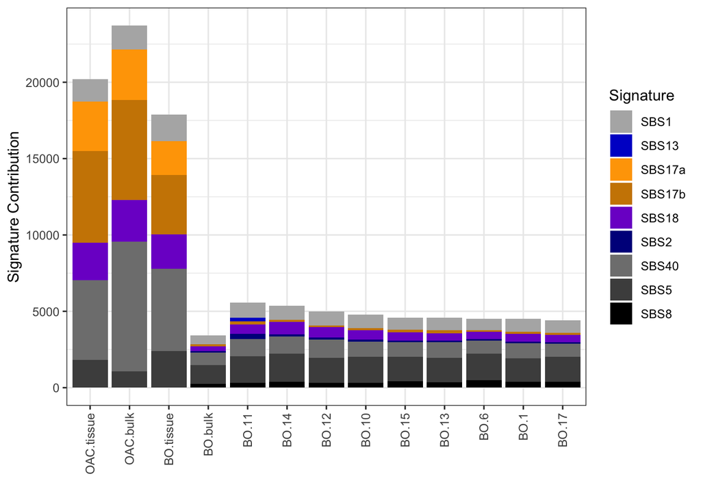

```r
# Since we already have the full set of somatic mutations in 'muts.full', we can jump straight in to generating input data for signature fitting.

# Fix the SPECIMEN_ID_short to include relevant tissues and OAC samples
muts.full$SPECIMEN_ID_short[muts.full$SPECIMEN_ID == 'AHM2392.BO-tissue'] <- 'BO.tissue'
muts.full$SPECIMEN_ID_short[muts.full$SPECIMEN_ID == 'OGD_AHM2392.T (OD)_INC_P5'] <- 'OAC.bulk'
muts.full$SPECIMEN_ID_short[muts.full$SPECIMEN_ID == 'AHM2392.T-tissue'] <- 'OAC.tissue'

muts.full$POS <- as.numeric(muts.full$POS)
muts.full <- muts.full %>%
  dplyr::filter(CHROM %in% paste0('chr',1:22))

# Generate counts matrices across branches
sigs.input <- mut.to.sigs.input(
  mut.ref = muts.full,
  sample.id = 'SPECIMEN_ID_short',
  chr = 'CHROM',
  pos = 'POS',
  ref = 'REF',
  alt = 'ALT',
  bsg = BSgenome.Hsapiens.UCSC.hg19
)

# Fix signatures matrix and match order to 'sigs.input'
sigs.hg37 <- read.table('Data/COSMIC_v3.3.1_SBS_GRCh37.txt', header = TRUE)
rownames(sigs.hg37) <- sigs.hg37$Type; sigs.hg37 <- sigs.hg37[,-1]
sigs.hg37 <- as.data.frame(t(sigs.hg37))
sigs.hg37 <- sigs.hg37[,colnames(signatures.cosmic)]

# Define signatures to be fitted
sigs.include <- paste0('SBS',c(1,2,5,8,13,'17a','17b',18,40))

# Run deconstructSigs
sigs.complete <- data.frame()

for (sample in rownames(sigs.input)) {
  # print(sample)
  sigs.i <- whichSignatures(tumor.ref = sigs.input,
                            signatures.ref = sigs.hg37[sigs.include, ],
                            sample.id = sample,
                            tri.counts.method = 'default',
                            contexts.needed = TRUE,
                            signature.cutoff = 0.02)
  sigs.complete <- rbind(sigs.complete, sigs.i$weights)
}

# Determine order of plotting (by decreasing mutation load)
mut.load <- muts.full %>%
  group_by(SPECIMEN_ID_short) %>% summarise(total_muts = n()) %>%
  arrange(desc(total_muts))

# Plotting contribution (signature proportion * total mutations)
sigs.complete$SPECIMEN_ID_short <- rownames(sigs.complete)
sigs.complete <- merge(x = sigs.complete, y = mut.load)
sigs.complete <- sigs.complete %>%
  pivot_longer(cols = c(SBS1,SBS2,SBS5,SBS8,SBS13,SBS17a,SBS17b,SBS18,SBS40),
               names_to = 'Signature', values_to = 'Proportion')
sigs.complete$Contribution <- round(sigs.complete$total_muts * sigs.complete$Proportion)
sigs.complete$SPECIMEN_ID_short <- factor(sigs.complete$SPECIMEN_ID_short,
                                          levels = mut.load$SPECIMEN_ID_short[c(2,1,3,13,4:12)]) # to ensure tissue and bulk organoid are first

ggplot(sigs.complete, aes(x= SPECIMEN_ID_short, y = Contribution, fill = Signature)) +
  geom_bar(stat = 'identity') + theme_bw() +
  scale_fill_manual(values = c('gray70','blue3','orange','orange3',
                               'purple3','darkblue','gray50','gray30','black')) +
  theme(axis.text.x = element_text(angle = 90, vjust = 0.5, hjust=1)) +
  labs(x = '', y = 'Signature Contribution')
```

```r
ggsave(filename = 'Results/AHM2392_signaturesBulk.pdf', height = 4.5)
df.anno <- merge(x = df.ploidy, y = df.tmb[,c('sequence_id','TMB')])
df.anno$sequence_id <- sapply(df.anno$sequence_id, function(x) str_replace(x,pattern='_',replacement='-'))

df.anno <- merge(x = df.anno, y = muts.oac_ann[,c('sequence_id','id_short')]) %>%
  dplyr::filter(!(id_short %in% c('BO.tissue','BO.bulk','OAC.tissue','OAC.bulk')))
names(df.anno)[4] <- 'case_id'

# Collate signature info
df.sigs <- sigs.complete %>%
  dplyr::select(SPECIMEN_ID_short, Signature, Proportion) %>%
  dplyr::filter(Signature %in% c('SBS17a','SBS17b','SBS18','SBS40')) %>%
  pivot_wider(names_from = 'Signature', values_from = 'Proportion') %>%
  mutate(SBS17 = SBS17a + SBS17b)

df.anno <- merge(x = df.anno, y = df.sigs, by.x = 'case_id', by.y = 'SPECIMEN_ID_short')
write.csv(df.anno, file = 'Results/Summary_ClonalOrganoids_AHM2392_annotation.csv')
```

Again, we establish here that the SBS17 contributions in the single clonal organoids are far lower than in the BO tissue. In this case (as opposed to AHM2149), the bulk-derived organoid also has susbstantially lower SBS17 burden.

## 2.2 Phylogenetic analysis

Using the same data for generating the signatures (excluding BO.tissue and BO.bulk), we can also determine the phylogenetic relationships between these organoids, and potentially infer when particular mutational processes were active.

```r
# Remove BO.bulk and BO.tissue (and all OAC samples) from 'muts.full', rotate the table to determine shared mutations across organoids, and define a Root sample with no mutations
muts.phylo <- muts.full %>%
  dplyr::filter(!(SPECIMEN_ID_short %in% c('BO.bulk','BO.tissue','OAC.bulk','OAC.tissue'))) %>%
  mutate(Present = 1) %>%
  dplyr::select(MUTATION_ID, SPECIMEN_ID_short, Present) %>%
  pivot_wider(names_from = SPECIMEN_ID_short, values_from = Present, values_fill = 0) %>%
  column_to_rownames(var = 'MUTATION_ID') %>%
  as.data.frame

muts.phylo <- muts.phylo[,sort(names(muts.phylo))] # this will come in handy when defining branches
muts.phylo <- cbind(muts.phylo, Root = 0)

# Convert to phyDat object
muts.phylo_obj <- as.list(muts.phylo)
muts.phylo_obj <- phyDat(data = muts.phylo_obj, type = 'USER', levels = c(0,1))
```

The tree itself is generated using the pratchet method, as defined in the phangorn R package.

```r
muts.phylo_treeMP <- pratchet(muts.phylo_obj)
```

[output not shown]

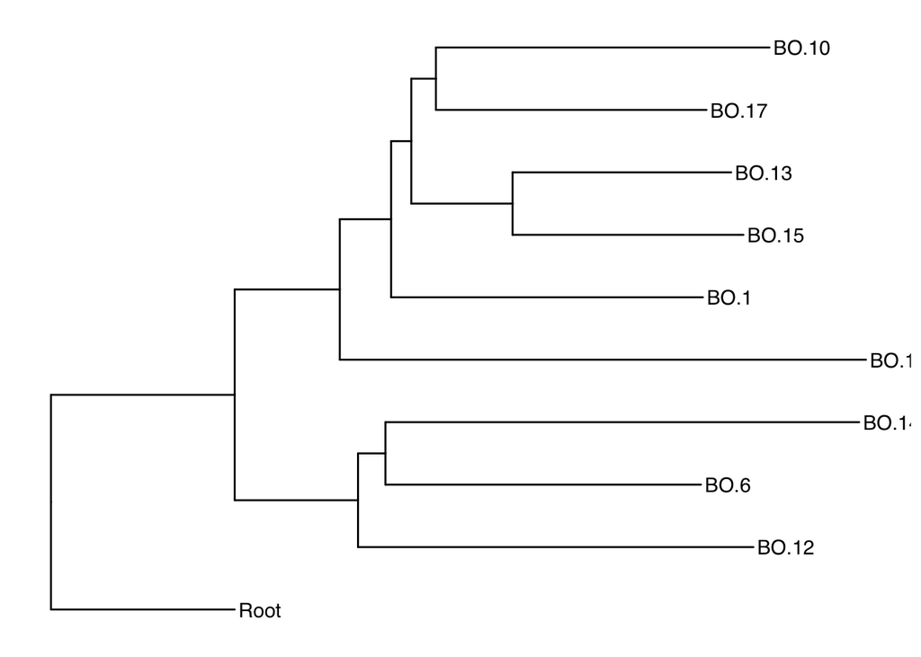

```r
muts.phylo_treeMP <- root(muts.phylo_treeMP, 'Root', resolve.root = TRUE)
muts.phylo_treeMP <- acctran(muts.phylo_treeMP, muts.phylo_obj)

p2 <- ggtree(muts.phylo_treeMP) + geom_tiplab()
print(p2)
```

## 2.3 Assigning signatures to branches

Here, signatures are assigned to branches by first assigning mutations to each branch existing on the above tree, and then fitting signatures directly to these. In this way, we can also determine what proportion of mutations are successfully matched to this particular tree.

Each branch is defined by determining all of its downstream tips. Any mutation appearing in each of these tips, and no others, is then assigned to that respective branch.

```r
# Define a function which returns downstream tips from each node
node.iterate <- function(data, node.select) {

  # Daughter nodes of a specific parent node defined by 'node.select'
  #   This may contain a combination of tips (isTip = TRUE) and branches (isTip = FALSE)
  #   Iteratively, we replace each case of isTip = FALSE with their respective branches/tips
  #   Until, for all cases, isTip = TRUE
  # We then output just the tip nodes
  df.tips <- data %>% dplyr::filter(parent == node.select)

  while (sum(df.tips$isTip == FALSE) > 0) { # e.g. if we already are at a tip

    df.notTip <- df.tips %>% dplyr::filter(!isTip)
    for (node_tmp in df.notTip$node) {

      data.node_notTip <- data %>% dplyr::filter(parent == node_tmp)
      df.tips <- rbind(df.tips, data.node_notTip)

      df.tips <- df.tips %>% dplyr::filter(node != node_tmp)

    }

  }

  tip.nodes <- sort(df.tips$label) # again, like previously, this is useful for branch naming/assignment

  # When there are no tip nodes (i.e. we started with a tip node), we simply output the relevant label for that tip
  if (length(tip.nodes) == 0) tip.nodes = p2$data$label[p2$data$node == node.select]

  return(tip.nodes)

}

# For each node, find the set of tips it is linked with
df.tip_match <- data.frame(
  node = p2$data$node,
  tips = sapply(p2$data$node, function(x) paste(node.iterate(p2$data, x),collapse='_'))
)

# For each mutation, label with character list of all organoids it is linked with
#   and check what proportion of mutations fit somewhere on the phylogenetic tree
muts.phylo$BRANCH <- apply(muts.phylo, 1, function(x) paste(names(x)[x==1], collapse='_'))
muts.phylo$MUTATION_ID <- rownames(muts.phylo)

# Print the proportion of mutations assigned to a branch defined in 'df.tip_match'
#   These represent the branches defined in the current tree
print(paste0('The total proportion of mutations assigned to the inferred tree is: ',
             round(100*mean(muts.phylo$BRANCH %in% df.tip_match$tips),2),'%'))
```

```
## [1] "The total proportion of mutations assigned to the inferred tree is: 93.32%"
```

Now that each mutation has been assigned a branch, we can assign signatures too!

```r
# Group MUTATION_ID for muts.all and match the relevant branch/organoid set
muts.branch <- muts.full %>%
  dplyr::filter(!(SPECIMEN_ID_short %in% c('BO.bulk','BO.tissue'))) %>%
  group_by(MUTATION_ID, CHROM, POS, REF, ALT) %>% summarise()
```

```
## `summarise()` has regrouped the output.
## ℹ Summaries were computed grouped by MUTATION_ID, CHROM, POS, REF, and ALT.
## ℹ Output is grouped by MUTATION_ID, CHROM, POS, and REF.
## ℹ Use `summarise(.groups = "drop_last")` to silence this message.
## ℹ Use `summarise(.by = c(MUTATION_ID, CHROM, POS, REF, ALT))` for per-operation
##   grouping (`?dplyr::dplyr_by`) instead.
```

```r
muts.branch <- merge(muts.branch, muts.phylo[,c('MUTATION_ID','BRANCH')])
muts.branch <- muts.branch %>% dplyr::filter(BRANCH %in% df.tip_match$tips)

# Generate counts matrices across branches
sigs.input <- mut.to.sigs.input(
  mut.ref = muts.branch,
  sample.id = 'BRANCH',
  chr = 'CHROM',
  pos = 'POS',
  ref = 'REF',
  alt = 'ALT',
  bsg = BSgenome.Hsapiens.UCSC.hg19
)
```

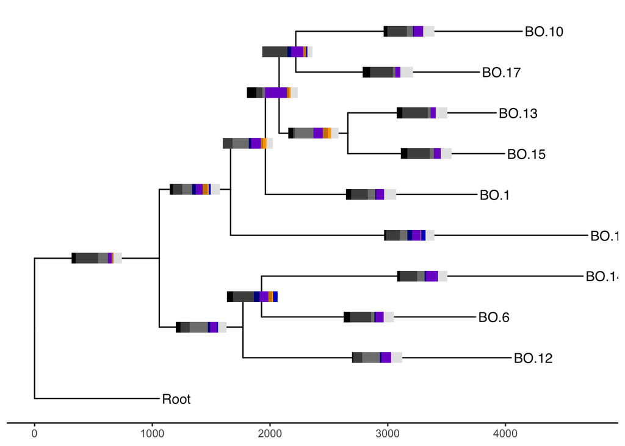

```r
# Subset on branches with fewer than 25 mutation
sigs.input <- sigs.input[apply(sigs.input, 1, sum) >= 25, ]

# Fix signatures matrix
sigs.hg37 <- read.table('~/Downloads/COSMIC_v3.3.1_SBS_GRCh37.txt', header = TRUE)
rownames(sigs.hg37) <- sigs.hg37$Type; sigs.hg37 <- sigs.hg37[,-1]
sigs.hg37 <- as.data.frame(t(sigs.hg37))
sigs.hg37 <- sigs.hg37[,colnames(signatures.cosmic)]

sigs.include <- paste0('SBS',c(1,2,5,8,13,'17a','17b',18,40))

# Run deconstructSigs
sigs.complete <- data.frame()

for (sample in rownames(sigs.input)) {
  # print(sample)
  sigs.i <- whichSignatures(tumor.ref = sigs.input,
                            signatures.ref = sigs.hg37[sigs.include, ],
                            sample.id = sample,
                            tri.counts.method = 'default',
                            contexts.needed = TRUE,
                            signature.cutoff = 0.02)
  sigs.complete <- rbind(sigs.complete, sigs.i$weights)
}

# Order by node
sigs.missing <- matrix(0, nrow=length(which(!(df.tip_match$tips %in% rownames(sigs.complete)))),
                       ncol = ncol(sigs.complete))
rownames(sigs.missing) <- df.tip_match$tips[which(!(df.tip_match$tips %in% rownames(sigs.complete)))]
colnames(sigs.missing) <- colnames(sigs.complete)

sigs.complete <- rbind(sigs.complete, sigs.missing)

sigs.complete <- sigs.complete[df.tip_match$tips, ]

# Plot pie charts
pies = list()
for (i in 1:nrow(sigs.complete)) {
  curr_dat = melt(sigs.complete[i,])
  curr_dat$variable <- factor(curr_dat$variable,
                              levels = sort(levels(curr_dat$variable)))
  ## create a ggplot object for each pie chart
  pies[[i]] =  ggplot(curr_dat, aes(y = value, fill = variable, x="")) +
    geom_bar(stat = "identity", width = .5) +
    # coord_polar("y", start=0) +
    coord_flip() +
    theme_void() + theme(legend.position = 'none') +
    scale_fill_manual(values = c('gray90','blue3','orange','orange3',
                                 'purple3','darkblue','gray50','gray30','black'))
}
# give them the appropriate names and plot on tree
names(pies) = 1:nrow(sigs.complete)
p2.overlap <- p2 + geom_inset(pies, width = 0.1, height = 0.07,
                              hjust = 0, x = 'branch') +
  theme_tree2()
p2.overlap
```

```r
ggsave(filename = 'Results/AHM2392_phyloSignatures.pdf', height = 5.5, width = 8.5)
```

# 3 RNA-seq analysis

```r
# Load new metadata and filter for clonal organoids (referred here as 'single cell derived organoids') from AHM2392
meta.rnaseq <- read_excel('Data/Pooled_sequencing_metadata_John Zhuang_RNAseq.xlsx') %>%
  dplyr::filter(Note == 'Characterization and clustering of phenotypes' &
                  `Case ID` == 'AHM2392' &
                  `Specimen phenotype` == "Barrett's" &
                  `...28` == 'single cell derived organoids') %>%
  mutate(`Specimen ID` = sapply(`Specimen ID`, function(x) str_replace(x, pattern = 'BE', replacement = 'BO'))) %>%
  mutate(ID_short = sapply(`Specimen ID`, function(x)
    gsub(pattern = 'AHM2392.', replacement = '',strsplit(x,split='_')[[1]][2])),
    sequence_id = sapply(`Sequencing ID`, function(x) gsub(pattern = '_', replacement = '.', x)))
# Create counts matrix
counts_list = counts.TPM_list <- list()
files.rnaseq <- list.files(path = 'Data/RNASeq', full.names = TRUE, pattern = 'rpkm_tpm.txt')

for (file in files.rnaseq) {

  file.counts <- read.table(file, header = TRUE) # sample info: read counts, FPKM, and TPM

  # Isolate sequence id
  sequence_id <- strsplit(strsplit(file, split='/')[[1]][3], split = '__')[[1]][1]

  # Save read counts in list
  counts_list[[sequence_id]] <- file.counts$readcounts_union
  counts.TPM_list[[sequence_id]] <- file.counts$TPM_union

}

counts <- do.call(bind_cols, counts_list) %>% as.data.frame
rownames(counts) <- rownames(file.counts) # Ensembl IDs
names(counts) <- meta.rnaseq$ID_short[match(names(counts), meta.rnaseq$sequence_id)] # sample IDs

counts.TPM <- do.call(bind_cols, counts.TPM_list) %>% as.data.frame
rownames(counts.TPM) <- rownames(file.counts) # Ensembl IDs
names(counts.TPM) <- meta.rnaseq$ID_short[match(names(counts.TPM), meta.rnaseq$sequence_id)] # sample IDs

# Generate SummarizedExperiment object
col_data <- meta.rnaseq[match(names(counts), meta.rnaseq$ID_short), ]

row_data <- ensembldb::select(
  EnsDb.Hsapiens.v79,
  keys = rownames(counts), # Ensembl IDs
  keytype = 'GENEID',
  columns = c('GENEID','SYMBOL')
)

counts <- counts[row_data$GENEID, ]

se.ahm2392 <- SummarizedExperiment(assays = as.matrix(counts),
                                   rowData = row_data, colData = col_data)

# Convert to DESeq object and conduct normalisation, including variance stabilizing transformation
dds.ahm2392 <- DESeqDataSet(se.ahm2392, design = ~ 1)
```

```
## renaming the first element in assays to 'counts'
```

```r
dds.ahm2392 <- dds.ahm2392[apply(counts(dds.ahm2392), 1, function(x) mean(x > 50) > .25), ] # remove lowly-expressed genes (i.e less than 25% of organoids have more than 50 reads)
dds.ahm2392 <- estimateSizeFactors(dds.ahm2392)

vsd.ahm2392 <- vst(dds.ahm2392, blind = FALSE)

# Generate annotation data frame, where we can add genomic info, and CDX2/MUC5AC expression
anno <- as.data.frame(colData(vsd.ahm2392)[,c('Specimen site', 'Case ID')])

anno$CDX2 = log2(counts.TPM['ENSG00000165556',]+1) %>% as.numeric
anno$MUC6 = log2(counts.TPM['ENSG00000184956',]+1) %>% as.numeric

anno$Alterations <- NA
anno$Alterations[rownames(anno) %in% c('BO.14')] <- 'APC stop'
anno$Alterations[rownames(anno) %in% c('BO.12')] <- 'FBXW7 stop'

# Generate heatmap with top 500 variable genes
topVarGenes <- head(order(rowVars(assay(vsd.ahm2392)), decreasing = TRUE), 500)
mat <- assay(vsd.ahm2392)[topVarGenes, ]
mat <- mat - rowMeans(mat)

# Generate colours gradient
paletteLength <- 255
myColor <- colorRampPalette(c("blue", "white", "red"))(paletteLength)
myBreaks <- c(seq(min(mat), 0, length.out=ceiling(paletteLength/2) + 1),
              seq(max(mat)/paletteLength, max(mat), length.out=floor(paletteLength/2)))

pheatmap(mat,
         annotation_col = anno[,-1],
         show_rownames = FALSE, show_colnames = TRUE,
         color = myColor, breaks = myBreaks,
         main = 'AHM/2392 (HGD)',
         filename = 'Results/AHM2392_RNAseqHeatmap.pdf',
         clustering_method = 'complete'
)
```

For additional insight, we can take a slightly closer look at our gastric and intestinal markers. Since Barrett’s tissue is a mosaic of cells displaying gastric and intestinal phenotypes, one could suggest that these organoids may represent clones which highlight either gastric or intestinal phenotypes. In this case, there is very little correlation between the gastric and intestinal markers, most likely indicating that these clones have retained a primarily gastric phenotype.

```r
# Generate heatmap of TPM-normalised gastric and intestinal markers

TPM.gastric <- counts.TPM[c('ENSG00000215182', # MUC5AC (gastric)
                            'ENSG00000184956', # MUC6 (gastric)
                            'ENSG00000165556', # CDX2 (intestinal)
                            'ENSG00000143167' # GPA33 (intestinal)
                            ),] %>% as.data.frame
rownames(TPM.gastric) <- c('MUC5AC','MUC6','CDX2','GPA33')
TPM.gastric <- log2(TPM.gastric + 1)

pheatmap(TPM.gastric,
         # color = myColor, breaks = myBreaks,
         filename = 'Results/AHM2392_RNAseq_HeatmapMarkers.pdf',
         main = 'AHM/2392 (HGD) - Gastric/Intestinal Markers')

# Note a marginal negative association between CDX2 and MUC6, and how MUC5AC deviates from what may be expected
df.marker_plot <- data.frame(
  sample_id = colnames(TPM.gastric),
  CDX2 = as.numeric(TPM.gastric['CDX2',]),
  MUC6 = as.numeric(TPM.gastric['MUC6', ])
)

ggplot(df.marker_plot, aes(x = CDX2, y = MUC6)) + theme_bw() +
  geom_point() +
  geom_smooth(method = 'lm') + stat_cor() +
  labs(x = 'CDX2 (log2-TPM)', y = 'MUC6 (log2-TPM)')
ggsave(filename = 'Results/AHM2392_RNAseq_GastricIntestinal.pdf')
```

[output not shown]